# Red wine analysis

### Plot Two

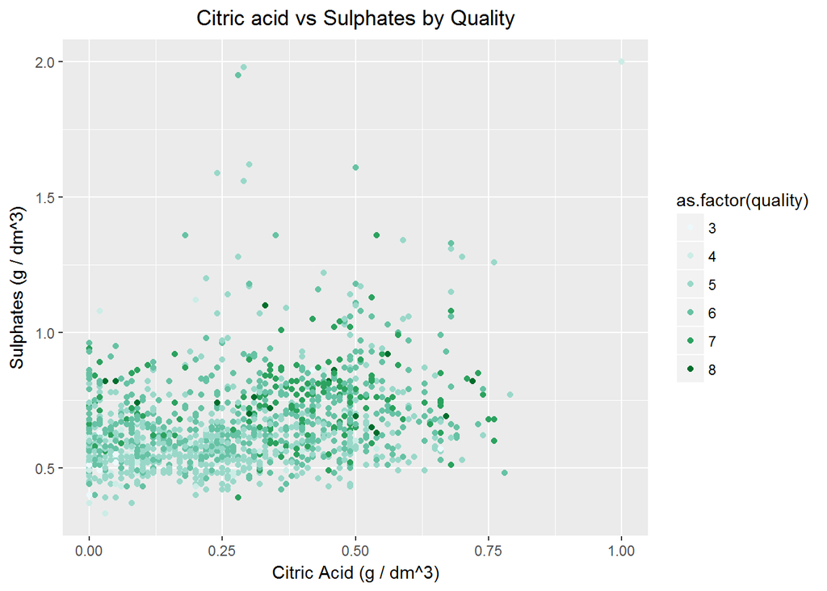

### Description Two

The citric acid vs sulphates graph is an important graph as they are two of the factors apart from alcohol percent that have a positive correlation with the quality. In high quality alcohols we can see an increased citric acid vs sulphates content.

### Plot Three

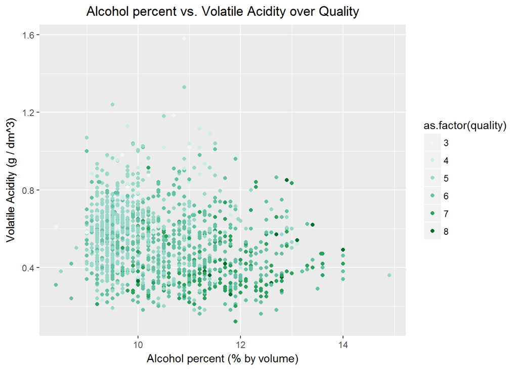

### Description Three

This plot highlightes the importance of volatile acidity and alcohol percent in accessing quality. Wines with higher percent of alcohol are usually good quality alcohols with low volatile acidity.

# Reflection

The dataset containes information about 1599 red wines across 13 variables from the year 2009.The goal was to find how the quality of wines vary with variables. Various plots were generated for the above purpose. Finally a linear model was created.Only 33.6% of the variance could be explained by the model created.

It took a while during analysis to determine which variables to compare.After quiet a while I was able to seperate the variables that affected the quality the most. There some confusion on which plots to use to best highlight the difference.Also I felt that the number of entries in the dataset could have been more for better prediction. The count of wines of quality 5 & 6 are higher compared to the rest. A close to even distribution of quality would have helped in better analysis.